# Question

Consider the radical function $f$ defined below.

$$f(x)~=~-\sqrt{-(x-3)}-4$$

We wish to indicate the domain and range of function $f$.

- Domain:
  - As an inequality: ##ANSWER1##
  - In interval notation: ##ANSWER2##
- Range:
  - As an inequality: ##ANSWER3##
  - In interval notation: ##ANSWER4##

## Answerlist

- x ≤ -4
- x ≥ -4
- x ≤ -3
- x ≥ -3
- x ≤ 3
- x ≥ 3
- x ≤ 4
- x ≥ 4
- y ≤ -4
- y ≥ -4
- y ≤ -3
- y ≥ -3
- y ≤ 3
- y ≥ 3
- y ≤ 4
- y ≥ 4
- [-4, ∞)
- (-∞, -4]
- [-3, ∞)
- (-∞, -3]
- [3, ∞)
- (-∞, 3]
- [4, ∞)
- (-∞, 4]
- x ≤ -4
- x ≥ -4
- x ≤ -3
- x ≥ -3
- x ≤ 3
- x ≥ 3
- x ≤ 4
- x ≥ 4
- y ≤ -4
- y ≥ -4
- y ≤ -3
- y ≥ -3
- y ≤ 3
- y ≥ 3
- y ≤ 4
- y ≥ 4
- [-4, ∞)
- (-∞, -4]
- [-3, ∞)
- (-∞, -3]
- [3, ∞)
- (-∞, 3]
- [4, ∞)
- (-∞, 4]

# Solution

A fully parameterized version of the given function could be written as:

$$f(x)~=~a\sqrt{b(x-h)}+k$$

In our case, we were given $f(x)~=~-\sqrt{-(x-3)}-4$, so

$$a = -1$$
$$b = -1$$
$$h =
3$$
$$k = -4$$

Because $a=-1$ and $b=-1$, the parent function is reflected vertically and horizontally, so from the starting point at (3, -4), the curve goes down and to the left.

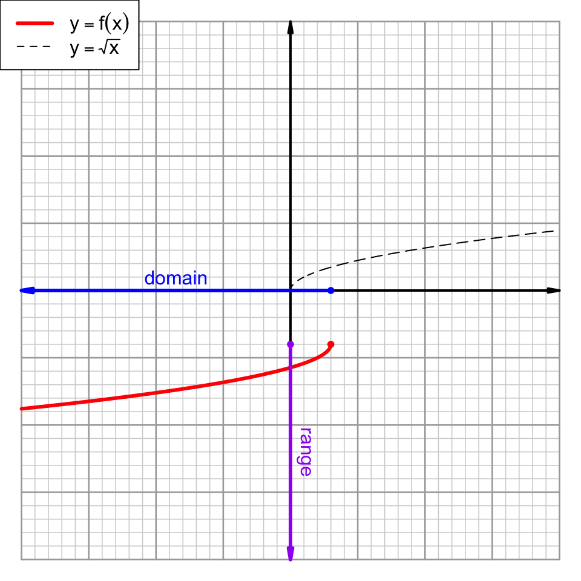

- Domain:
  - As an inequality: x ≤ 3
  - In interval notation: (-∞, 3]
- Range:
  - As an inequality: y ≤ -4
  - In interval notation: (-∞, -4]

# Meta-information

extype: cloze exclozetype: schoice|schoice|schoice|schoice exsolution: 0000100000000000|00000100|0000000010000000|01000000 exname: radical_dom_rng